# Closer look to InfoGears dataset

Myasnik Khachkalyan

7/19/2020

## Dataset

The dataset is provided by InfoGears. The aim of the dataset is to monitor public health, by relying on crowdsourcing and self-reporting. The observations are anonymous. The data is collected by having a assessment quiz which one can find in the infogears.org website. The target audience is US people mostly, targeted Glendale, Burbank, Pasadena (California) and neighboring areas, which are differentiated using zip codes. The structure of the dataset u can find bellow.

```
## 'data.frame':    30088 obs. of  32 variables:
##  $ age_interval       : chr  "interval_36_45" "interval_26_35" ...
##  $ antibodyTest       : chr  "notTested" "notTested" ...
##  $ createdAt          : num  43937 43937 ...
##  $ exposureLevel      : chr  "doNotKnow" "doNotKnow" ...
##  $ faceCovering       : chr  NA NA ...
##  $ gender             : chr  "male" "male" ...
##  $ guid               : chr  "b91c76ab-449a-4b2b-985a-60dd57d17145" "24ad589e-adc0-47ae-9515-63e77979b422" ...
##  $ healthIssues       : chr  "noIssues" "noIssues" ...
##  $ householdHeadcount : num  4 2 4 4 4 ...
##  $ ip                 : chr  "174.193.218.227" "107.185.158.57" ...
##  $ leftHomeTimes      : chr  "didNotLeave" "didNotLeave" ...
##  $ mentalHealthImpact : chr  "someImpact" "someImpact" ...
##  $ updatedAt          : num  43937 43937 ...
##  $ virusTest          : chr  "notTested" "notTested" ...
```

[output cut: 18 more lines]

Besides some minor finding there will be some hypothesises , which will be proven by the graph.

- The hyposesises are:
  - The more members of the family the more impact to the mental health of the person.
  - Even if one does not have any symptoms that does not guarantee that he/she is not infected.
  - Wearing masks or face covering when leaving home is helping at least developing serious symptoms of Covid, thus lowering the risk of being infected.

In the end there will also be a small prediction section. Using number of infecteds and some other factors in from ourdateset we will find out approximately how many more infected people are there that are not in our dataset.

## State Distribution

As already was said the targeted Glendale, Burbank, Pasadena (California). To test whether they got the result they wanted, the I generated a table, which u could se above. Also, we can see what cities and states are the most active in doing the assessments of the InfoGears website.

Top 20 States and Cities by the number of observations

| State | Count |
| --- | --- |
| California | 20565 |
| Florida | 1428 |
| Texas | 1107 |
| Pennsylvania | 761 |
| Ohio | 584 |
| New York | 506 |
| Arizona | 420 |
| Michigan | 409 |
| Illinois | 336 |
| Indiana | 327 |
| North Carolina | 271 |
| Wisconsin | 186 |
| Georgia | 184 |
| Virginia | 177 |
| Missouri | 170 |
| Alabama | 167 |
| Tennessee | 166 |
| South Carolina | 158 |
| Minnesota | 151 |
| Iowa | 144 |

| City | Count |
| --- | --- |
| Los Angeles | 18869 |
| Orange | 554 |
| San Bernardino | 243 |
| Maricopa | 233 |
| Harris | 192 |
| Ventura | 174 |
| Riverside | 169 |
| San Diego | 125 |
| Jefferson | 117 |
| Montgomery | 114 |
| Bexar | 109 |
| Lake | 107 |
| Miami-Dade | 105 |
| Hillsborough | 97 |
| Marion | 97 |
| Palm Beach | 97 |
| Cook | 96 |
| Broward | 95 |
| Pinellas | 88 |
| Washington | 82 |

As we can notice from the tables, the absolute winner is State California, and city Los Angles. Also, we can infer from the graph that the target that InfoGears set was gotten partially.

As California is has the most number of observations let’s see its numbers distributed in the days and month separately to have a nicer look of it. Also, fill find where was the pick in California.

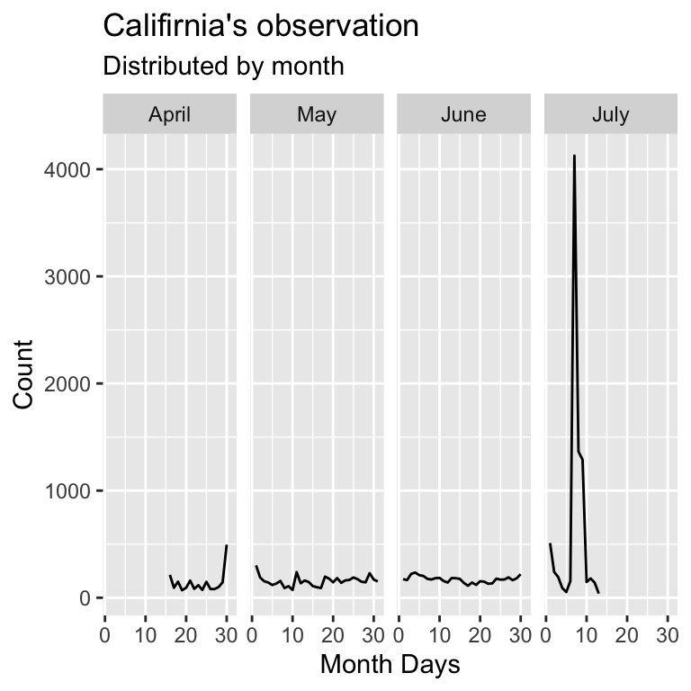

The graph might seem incomplete but its not, because the observations started in mid April and my resulted dataset has observations till mid July. From the graph we can infer that around 5-10th of July was the pick for number of observations from California. All other days have relatively similar result having numbers around 150-250.

Let’s see how other Top 10 states are doing. In the graph bellow will show number of observation through time for Top 10 states other than California

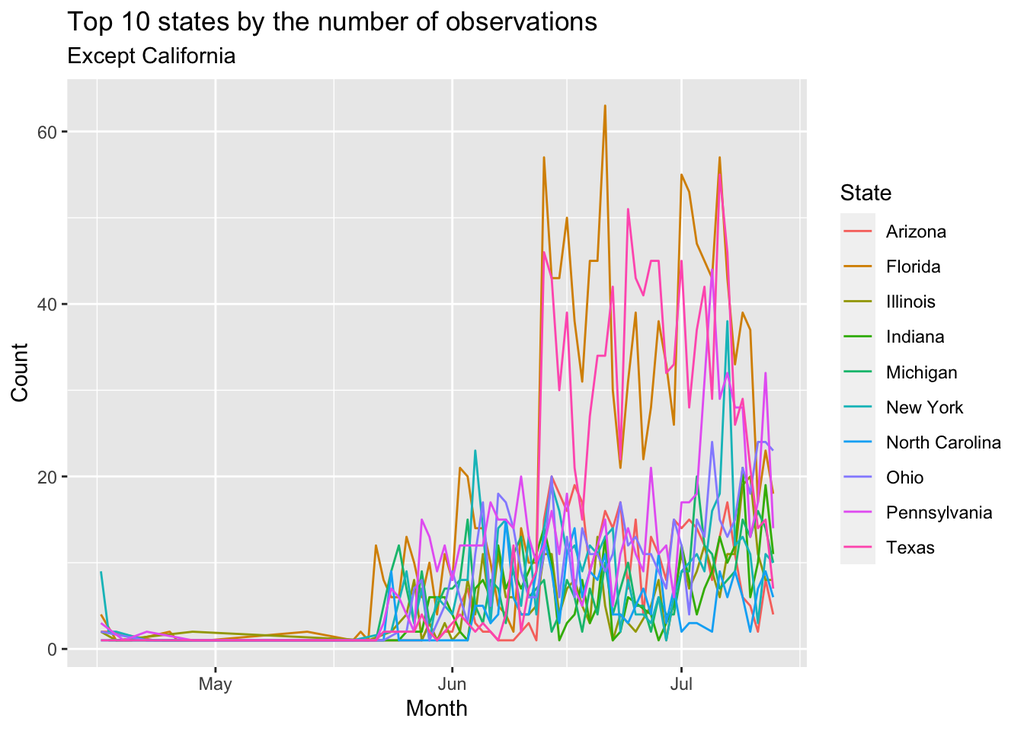

Each big break in the graph corresponds to the 1th of that month, April is not visible as label because observation started from April 16. The each state is a individual line wiht its own color. You can find the State-color touples in the right of the plot. We can see that almost in all states the pick of the number of the observations in the day is reached from mid Jun to mid Jul.

## Gender distibutions in the dataset

After doing some claen ups in the gender column of of the dataset we got 3 genders types. The standard ones, male and female, and all other observations which either did not mention the gender or mention another gender is under label other. Let’s see the distribution of the gotten column in the graph bellow.

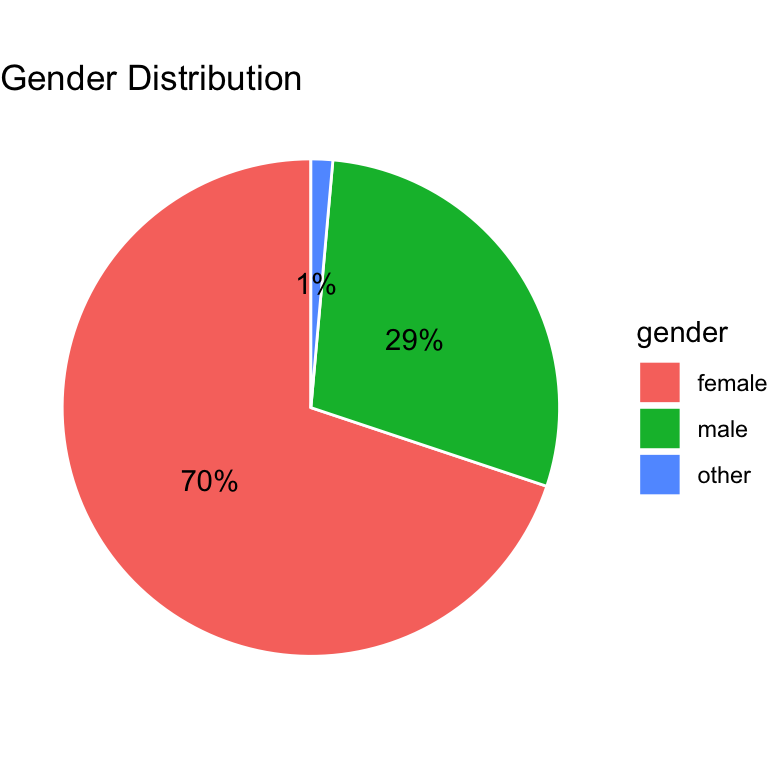

As we can see around 70 percent of the assessments are done by the female. The percentage of the males is 29, and the left 1 percent is all other observation having gender neither female nor male.

## Age distribution in the dataset

In the dataset the coulumn about ages is age_interval coulumn. It includes 8 groupes of ages in which the observations are distributed.

- Those groupes are
  - under 18
  - from 18-25
  - from 26-35
  - from 36-45
  - from 46-55
  - from 56-65
  - from 66-75
  - above 75

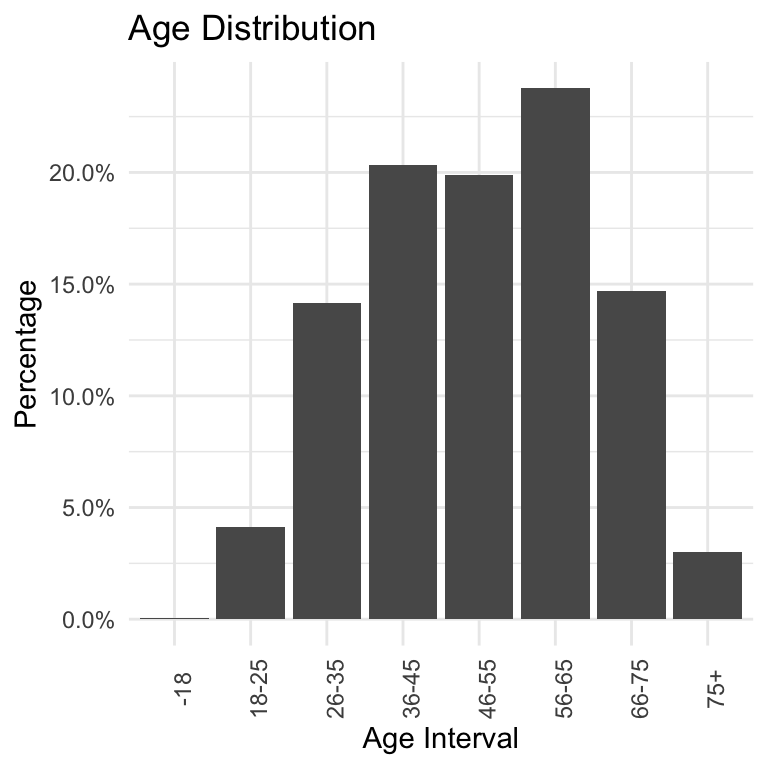

As we saw in the graph most of the observant are between 56 and 65. The least percentage have the age interval bellow 18, which is almost 0. The second least one is above 75, around 3 percent. The observations having age interval 26-35 and 66-75 has almost equal percentages(around 14.5) in the dataset. The same can be said about 36-45 and 46-55, but those have higher percentage (around 20) than those two.

## Positive cases

Arguably the most important column is virisTest column, which indicates the person doing the assesment had been tested positively, negatively or had not bee tested at all. On this column will take another look when doing predictions on the dataset.

- Number of
  - positive tests is 204
  - negative tests is 4382
  - the rest had not been tested

Let’s see the distrubution among gender and age interval of people with positive tests in the graph bellow.

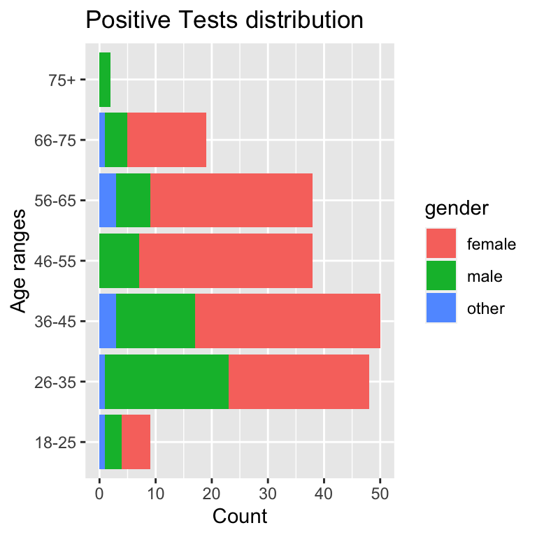

As you can infer from the graph the most part of the infected people are of age from 36 to 45 and most of them are female.

- Other facts:
  - All people with the positive cases above 75 are males.
  - In the age interval of 26-35 the distribution amount males and females are equal.
  - The age intervals 46-55 and 56-65 have same number of positive cases but the gender distribution is slightly different
  - The age interval bellow 18 does not have any observation with positive test.

## Mental Condition

Mental state is very important in lockdown days. The mental health of a person can easily be infected as he/she sits at home all day with the thoughts of not being infected, and worrying about his/her health and health of the close people. Some studies show the a lot of people’s mental condition suffered because of the Corona virus and total lockdown, due to the factors that I have mentioned above and others as well. Another important factor can be the number of household that one lives. Of course they were part of the every day life before the lock down, but for some people being all days for months the with the same people for 24/7 might be a hard task. Think what will be with the mental condition of that percon if the number of household is big.

Hypothesis: The more members of the family the more impact to the mental health of the person.

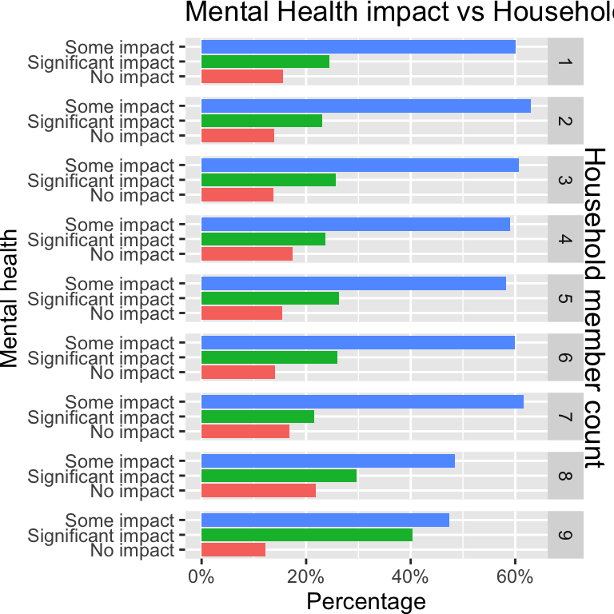

The graph above shows that there was some or significant impact on most of the observants’ mental health.

The blue bar shows us that almost in any number household there was some impact. In out hypothesis we mention the more the household the more the impact, and it might seem we have a contradiction here as some impact bar high is for households with 1, 2, 3. We mention the one side of the coin, the other one the case we have here luck of communication, i guess. Of course we cant say for sure because, when we talk about some impact different people mean different aspect.

The bar we are interested more for this hypothesis is the green one. And we defenetely can see that its the highest for the house holds with 8 and 9 people. Households with 1, 3, 5 and 6 members have relative same percentage. The most surprising here is the observations with 7 member household. All other are almost what we expected.

## Symptoms and Virus positive tests

Being aware of symptoms and be ready to react to them is very importannt in this pandemic. Of course having no symptoms means that the chance of being infected with corona virus is low. But not 0.

Hypothesis: Even if one does not have any symptoms that does not guarantee that he/she is not infected.

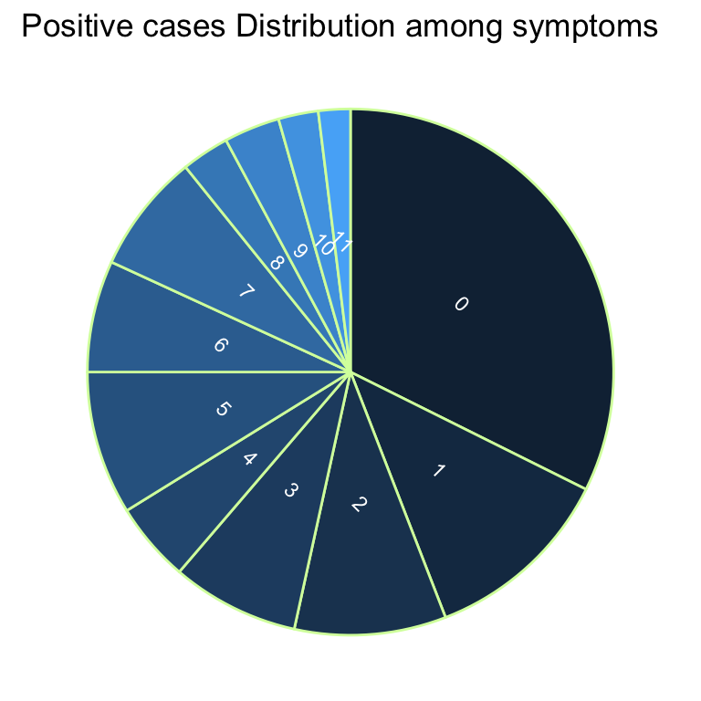

The numbers indicate number of symptoms.

## The more the Age the more the Symptoms

The number of observants having serious symptoms which are temperature, persistent cough and breathing difficulties, is 1179. Not surprisingly most of them are of age from 46 and more, as it has been told from the day one that virus is more dangerous for elder people, so there will be more symptomes for them. See the bar chart bellow.

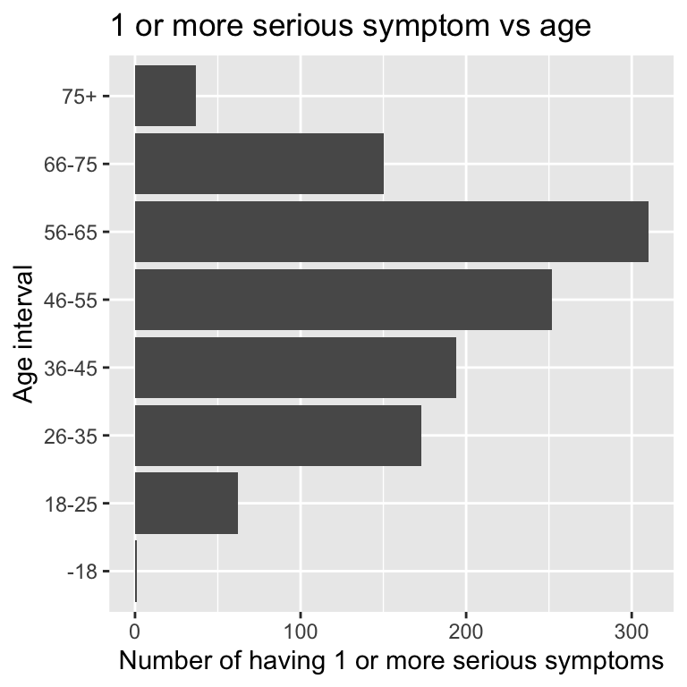

## Distribution between reason for leaving home and the age

To leave home in this pandemic is always a risk. There are couple of reasons in our dataset why people left home. Let’s see whether the reason worth the risk or not.

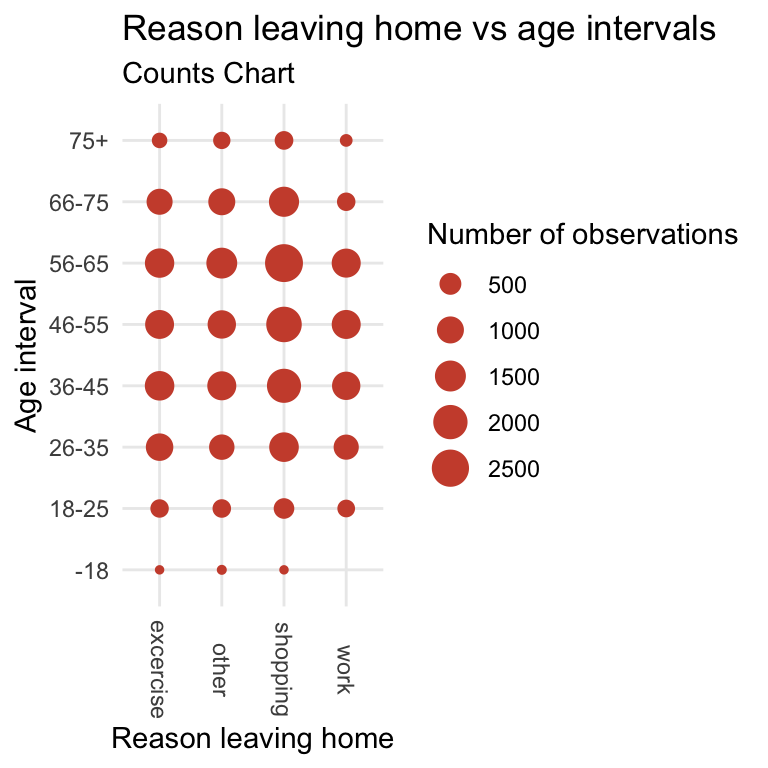

As we see most nuber of people, arount 2500, left home for shopping and they were age of 56-65. In the next graph will see more datailed version of the graph above.

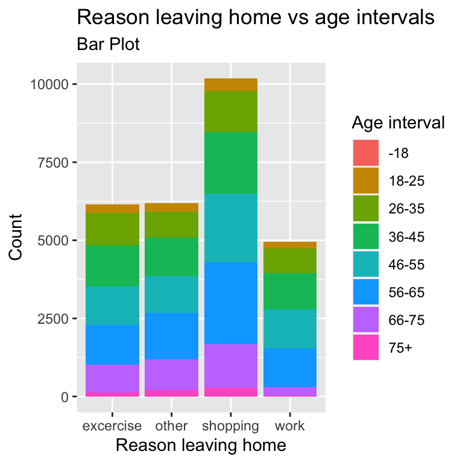

Shoping is valid reason to leave home. People must do grocery shopping to live and have a good imune system to overcome this hard times. Leaving for wxercise is also a good reason to leav home to stay healthy and a healthy lifestyle. Surprisingly people leaving home for work is less that for other affairs. We dont know what each person meant by other so let’s not judge)

## Face covering effeciency

Wearing masks and covering your face is very important, but there are still some uncertainties whether they are effective or not. Well, as most of the people in the detaset are not tested, I will try to answer that question using the number of serious symptoms. Again having no symptoms does not guarantee that one is not infected, but still the probability is very low being infected.

Hypothesis: Wearing masks or face covering when leaving home is helping at least developing serious symptoms of Covid, thus lowering the risk of being infected.

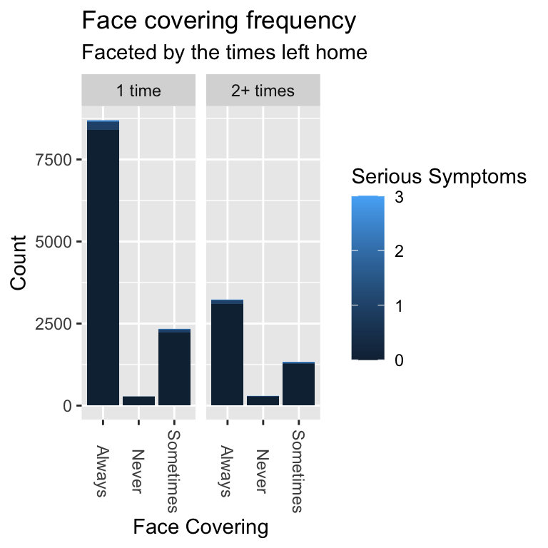

On the graph above we can see that wearing face coverings always or sometimes help be safe and don’t catch any symptoms, as number of those wearing masks and having 0 serious symptoms is way more that those who wore mask or face covering and caught a serious symptom.

## Thos who does not wear face coverings does not risk only themselves, also their household members.

By not wearing face covering we not only risk our health but also health of household members.

Let’s see how much people’s health are endangered by because of irresponsible ones. We will concentrate on those having direct contact with infected people.

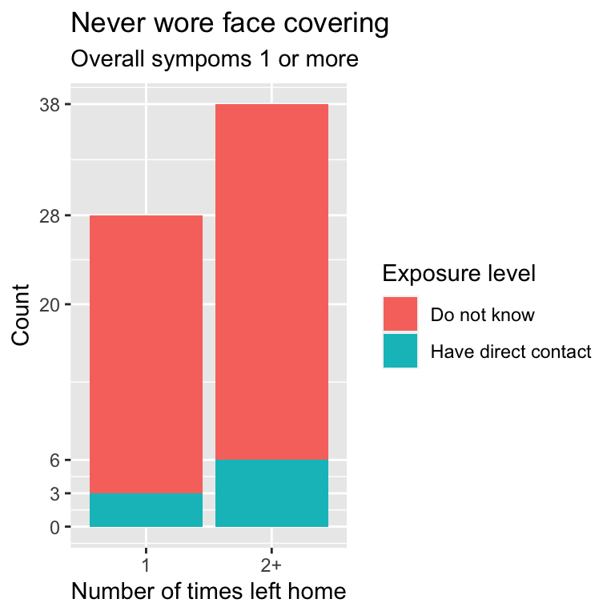

Number of people from different ip having direct contact with infected person is 6 Mean of household count among them is 3 Those who did not wear face covering and have contact with infected people are most probably infected as well. By having the numbers above we can calculate how many people have high probability of being infected. Via calculations we can find that probably around 18 more people are infected.

## More cases than we see

Number of people tested positive in our dataset is 204, from which unique IPs have 187 That means we can assume that 187 household have at least one infected member Rounded mean number of house hold members of those unique cases is 3 If there is one or more infected people in the household the chance of other members being infected is very high. That being said, we can calculate how much people approximately is infected but is not in our observations’

Possible number of people which we can get based on our dataset, not included in it, is 374

Let’s also not forget the number we got from calculations above Thus, over all number of possibly infected that we don’t have in our dataset is 392.

## Conclusion

InfoGears is doing a great job of collecting all this data. This helps people of US stay aware whether there are infected people in their neighborhoods or not. They have a lot of great charts and visualizations in their website(infogears.org). Due to this dataset in this report we also found some interesting findings, such as what age group was the most active doing this assessments, and we can infer that people of that age group might also be the overall more informed and concerned ones. We found out what is the most common reason for people to leave home. Along side this we have learn what is people’s attitude towards wearing face coverings, and about the effectiveness of it. We found the distribution of symptoms among age. We have proved couple of well known and not so much hypothesises using the dataset. We also tried to to some predictions about the number of people who might be infected but are not in our dataset as a possitive tested cases. Hope you enjoyed the report and also found some interesting facts which might help you to be awere,